# stranger weirds methods

WeLoveDataScience

2018-03-12

In this vignette, we introduce every method available in `stranger` package. Note that methods may require extra packages.

We will work with iris dataframe and use `lucky_odd` function.

The list of cuttently available wrappers / weirds methods is listed below (one can use `weirds_list` function to obtain them).

| weird_method | name | package | package.source | foo | detail |
| --- | --- | --- | --- | --- | --- |
| Angle-based Outlier Factor | abod | abodOutlier | CRAN | abod | Numeric value (outlier factor) |
| autoencode | autoencode | autoencoder | CRAN | autoencode | Positive numeric value (probability) |
| isolation Forest | isofor | isofor | github | iForest | Positive numeric value (distance) |
| kmeans () | kmeans | stats | CRAN | kmeans | Positive numeric value (distance) |
| k-Nearest Neighbour | knn | FNN | CRAN | knn.dist | Positive numeric value (distance) |
| Local Outlier Factor | lof | dbscan | CRAN | lof | Positive numeric value (local outlier factors) |
| Mahalanobis distance | mahalanobis | stats | CRAN | mahalanobis | Positive numeric value (distance) |
| Semi-robust principal components > distances | pcout | mvoutlier | CRAN | pcout | Positive numeric value (distance) |
| randomforest outlier metric | randomforest | randomForest | CRAN | randomForest | Positive numeric value (distance) |

Following some helper function is introduced to simplify code apparing in each chunk.

```r
anoplot <- function(data,title=NULL){
  g <- ggplot(data, aes(x=Sepal.Length,y=Sepal.Width,color=Species,size=flag_anomaly))+geom_point()+scale_size_discrete(range=c(1,3))
  if (!is.null(title)) g <- g+ ggtitle(title)
  return(g)
  }
```

## abod

```
## *** weird method Angle-based Outlier Factor
## abod based on function abod [abodOutlier]
## Metric: Numeric value (outlier factor) sorted in increasing order.
```

Note: during submission on CRAN, it seems `abodOutlier` package was not available.

```r
iris %>%
  lucky_odds(n.anom=6, analysis.drop="Species", weird="abod") %>%
  anoplot(title="abod - default parameters")
```

Default values for `abod` parameters:

- k=10
- … additional parameters to be passed to `abod` (`method` and `n_sample_size` - see `?abod`.

Extra parameters used in `stranger` for this weird: none.

Default naming convention for generated metric based on *k*.

**NOTE**: this method is not recommended for volumetric data.

From `abod` help:

Details

Please note that ‘knn’ has to compute an euclidean distance matrix before computing abof.

Value

Returns angle-based outlier factor for each observation. A small abof respect the others would indicate presence of an outlier.

## autoencode

```
## *** weird method autoencode
## autoencode based on function autoencode [autoencoder]
## Metric: Positive numeric value (probability) sorted in decreasing order.
```

```
## autoencoding...
## Optimizer counts:
## function gradient
##      175       52
## Optimizer: successful convergence.
## Optimizer: convergence = 0, message =
## J.init = 41.81721, J.final = 0.3669452, mean(rho.hat.final) = 0.001234119
```

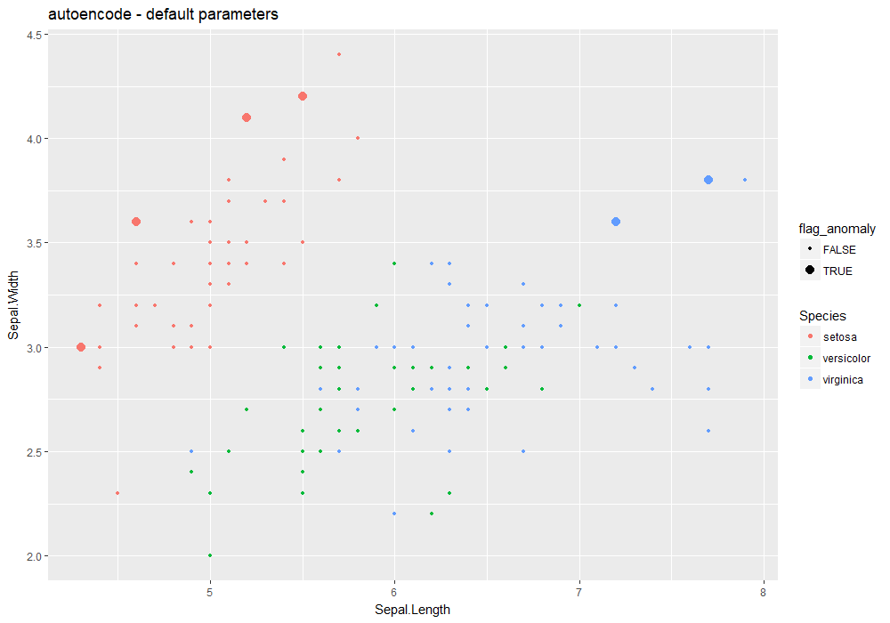

```r
iris %>%
  lucky_odds(n.anom=6, analysis.drop="Species", weird="autoencode") %>%
  anoplot(title="autoencode - default parameters")
```

Changing some parameters:

```
## autoencoding...
## Optimizer counts:
## function gradient
##       27        3
## Optimizer: successful convergence.
## Optimizer: convergence = 0, message =
## J.init = 41.81726, J.final = 1.626723, mean(rho.hat.final) = 1.752925e-12
```

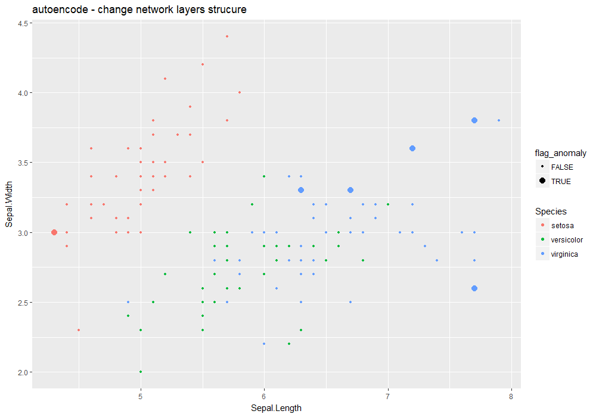

```r
iris %>%
  lucky_odds(n.anom=6, analysis.drop="Species", weird="autoencode",nl=4, N.hidden=c(10,8),beta=6) %>%
  anoplot(title="autoencode - change network layers strucure")
```

Default values for `autoencode` parameters:

- nl=3
- N.hidden=10
- unit.type=“tanh”
- lambda=0.0002
- beta=6
- rho=0.001
- epsilon=0.0001
- optim.method=“BFGS”
- max.iterations=100
- rescale.flag=TRUE
- …: user may pass other parameters to `autoencode` (rescaling.offset).

Extra parameters used in `stranger` for this weird: none.

Default naming convention for generated metric based on *nl* and *n.hidden*.

From `autoencode` package: An autoencoder neural network is an unsupervised learning algorithm that applies backpropagation to adjust its weights, attempting to learn to make its target values (outputs) to be equal to its inputs. In other words, it is trying to learn an approximation to the identity function, so as its output is similar to its input, for all training examples. With the sparsity constraint enforced (requiring that the average, over training set, activation of hidden units be small), such autoencoder automatically learns useful features of the unlabeled training data, which can be used for, e.g., data compression (with losses), or as features in deep belief networks.

Usage here is to learn an autoencoder then apply it to same data and look at high residuals.